# R Tutorials: Robustness Assessment of Regressions using Cluster Analysis Typologies

# Extended Tutorial

In the following subsections, we present several extensions and complementary analysis that can be really helpful to make the most of the RARCAT results and better interpret the outcome. Generally speaking, the Robustness Assessment of Regressions using Cluster Analysis Typologies (RARCAT) procedure works as follows:

1. A random sample with replacement (i.e, bootstrap) is drawn from the data.
2. The bootstrap sample is clustered, applying the exact same clustering procedure as the one used in the original analysis, which implies using the same dissimilarity measure, cluster algorithm, and method to determine the number of clusters.
3. A separate logistic regression predicting membership probability in each group is estimated.
4. The AME of each covariate on the probability to be assigned to a given type is retrieved for all sequences belonging to this type.
5. These steps are repeated $N$ times, with $N$ typically large.
6. The AMEs from step 4 are pooled using a multilevel modelling framework.

In this section we further detail some of these steps. First, we consider the estimation of the number of clusters (instead of using a `fixed` number). Second, we analyse the AME estimated in each bootstrap and their distribution by cluster. This provides relevant information on which clusters lead to stable or unstable results. We then discuss several diagnostics and check to ensure that a sufficient number of bootstraps have been used. We finally discuss how to investigate the stability of the clustering itself and its potential impact on the regression results.

## Estimating the Number of Clusters

Usually, the number of groups of a typology is not known in advance, but rather estimated from the data, for instance by maximizing (or minimizing) a given cluster quality index. The RARCAT procedure can account for the estimation of the number of groups chosen through CQI maximization (or minimization). This is achieved by specifying `fixed=FALSE`, the maximum number of groups to consider (here `ncluster=10`) as well as the target CQI (here the Hubert’s C index). To limit computation time, we only used `R=50` here, but this should be increased in any application.

```r
# Bootstrap replicates of the typology and its association with the variable funemp.
# As in the original analysis, hierarchical clustering with Ward method is implemented.
# Also, an optimal clustering solution with n between 2 and 10 is evaluated each time by
# maximizing the HC index.

# As we previously initalized parallel computing, it is used in these computations
vary.rarcat <- rarcat(clustering ~ funemp, data = mvad, diss = diss, R = 50,
                       kmedoid=FALSE, hclust.method = "ward.D",
                       fixed = FALSE, ncluster = 10, cqi = "HC")
vary.rarcat
```

```
##
##  NAIVE ESTIMATES
##  Average Marginal Effect (AME) to be in a given cluster instead of any others
##           Cluster 1       Cluster 2          Cluster 3        Cluster 4
## funempyes -0.0447         -0.0412            0.00878          0.0927
##           (-0.13; 0.0407) (-0.0874; 0.00509) (-0.0734; 0.091) (0.00205; 0.183)
##           Cluster 5         Cluster 6
## funempyes -0.0797           0.0641
##           (-0.131; -0.0285) (0.00462; 0.123)
##
##  ROBUST ESTIMATES (RARCAT)
##  Average Marginal Effect (AME) to be in a given cluster instead of any others
##
##  Number of bootstraps:  50  with  varying  number of clusters
## Distribution of the number of clusters across bootstraps
##
##  4  5  6  7  8  9 10
##  3  2  1  3  2 15 24
##
##           Cluster 1         Cluster 2         Cluster 3
## funempyes -0.0229           -0.033            -0.0113
##           (-0.0862; 0.0403) (-0.0943; 0.0283) (-0.0413; 0.0186)
##           Cluster 4        Cluster 5        Cluster 6
## funempyes 0.0205           -0.08            0.0871
##           (-0.017; 0.0581) (-0.135; -0.025) (-0.0086; 0.183)
```

Time for this code chunk to run: 10.91 seconds

## Plotting the AME

RARCAT works by estimating for each observation the AME of its cluster in each bootstrap. We can plot these AME (across individuals and bootstraps) using the `plot()` function and specifying the `covar` (covariable) of interest.

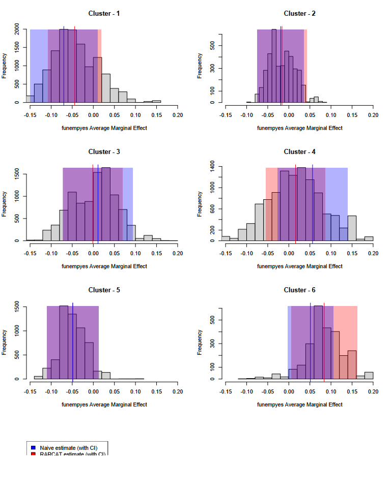

```r
# Histogram of the estimated AMEs for all individuals and all bootstraps
plot(rarcatout, covar="funempyes")
```

Time for this code chunk to run: 0.21 seconds

The plot also shows the estimated overall AME using the naive (in blue) or RARCAT approach (in red). Corresponding confidence intervals are also represented using colored shaded area.

For some clusters, we identify an unimodal distribution of the AME, usually with a low dispersion. This denotes that the results for this specific cluster are stable. The observations initially regrouped in this cluster were clustered in clusters with similar AME values across the bootstraps. We can therefore be confident about our interpretation (whether a positive, negative, neutral association).

On the contrary, if there’s a large dispersion of the AME, the bootstraps lead to the estimation of different values, showing less stable results. We can therefore be less confident and the RARCAT confidence interval will generally be larger.

Multimodal distributions of the AME generally reveal an interesting situation. It often means that a subgroup of observations switch to a different cluster, with a different AME, in several of the bootstraps. This can happens for instance in presence of observation lying in-between types. We can identify those observations by looking at the outliers (see below).

## Pooling Effect Sizes

The final RARCAT estimates are computed or pooled using a multilevel models. This model allows identifying the pooled estimate and its the expected variation across bootstraps. It also allows us to identify outliers.

### Diagnostics

We rely on a cross-classified multilevel model, using bootstrap and indiviudal as upper level, to pool the results. The residual standard errors provides us information on the remaining estimation related to the bootstrapping procedure. It should therefore be low if we have a sufficiently large number of iteration. The `summary()` function provide several informations.

```r
summary(rarcatout)
```

```
##
## RARCAT Diagnostics
## Distribution of standardized observation random intercept
##
##  funempyes
##
##     < -2 -2....-1   -1...1    1...2       >2
##        2       54      567       69       20
##
##
##  gcse5eqyes
##
##     < -2 -2....-1   -1...1    1...2       >2
##       12       53      583       17       47
##
##
## Standard errors
##                      1           2           3           4           5
## funempyes  0.003576662 0.002978417 0.003737584 0.003983932 0.003075888
## gcse5eqyes 0.008404634 0.003879203 0.005412312 0.004271173 0.004193584
##                      6
## funempyes  0.004280292
## gcse5eqyes 0.004535972
```

Time for this code chunk to run: 0.02 seconds

In our example, the standard errors are low. The number of bootstrap was therefore sufficient. If those numbers are too high, increasing the number of bootstrap should fix it.

### Outliers

The previous output also shows the number of outliers for each covariate. These observations lies far from the average estimate in at least some of the bootstrap. Interestingly, outliers are generally regrouped in some of the clusters only. We can look at the distribution of standardized observation-level random effects per clusters. These random effects can be interpreted as estimated deviation from the pooled estimates. Therefore, we can use them to identify observations (i.e. sequences) that are not well represented by their pooled estimates.

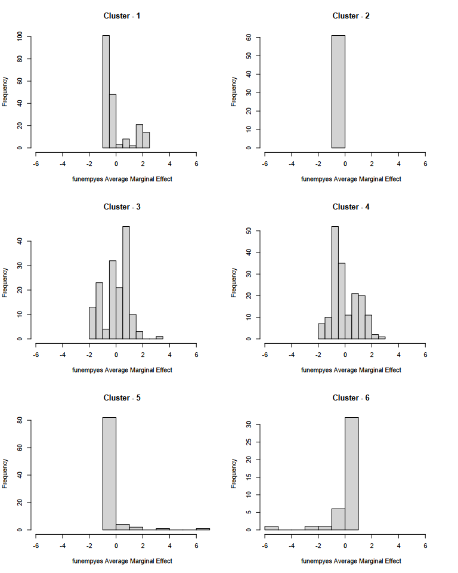

```r
plot(rarcatout, what="ranef", covar="funempyes")
```

Time for this code chunk to run: 0.12 seconds

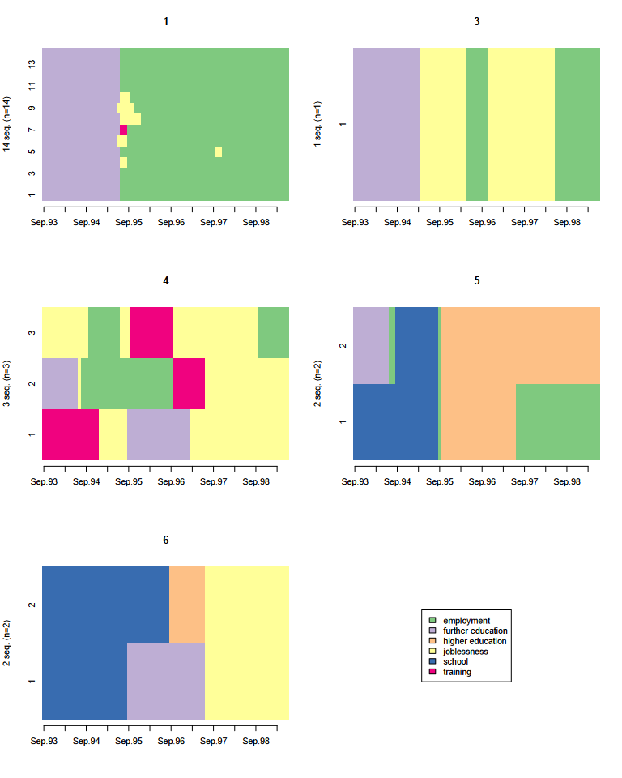

```r
outliers <- abs(rarcatout$observation.stdranef[, "funempyes"])>2
seqIplot(mvad.seq[outliers, ], group=mvad$clustering[outliers])
```

Time for this code chunk to run: 0.28 seconds

Interestingly, there are no deviating sequences in some of the clusters.

Lastly, the individual-specific random effects in the output of `unirarcat` inform on the within-cluster homogeneity. Indeed, individuals with fitted values that diverge from the other individuals in the same cluster were often assigned to different clusters in the bootstrap, thus impacting their estimated AMEs. We can see this by looking at the distribution of these random effects.

## Bootstrap replicates of the typology

There are several reasons that might lead to non-robust results. Being able to distinguish them allows for a better understanding of RARCAT results.

One of them relies on the stability of the clustering results. The clustering (i.e. the estimation of the typology) might be sample dependent. As a result, inference and interpretation should be made with extreme caution. Hennig (2007) proposed to look at the cluster stability across difference bootstraps to estimate this sampling uncertainty. The analysis allows to identify specific clusters that stable or not across bootstraps. The method is available in the `fpc`package and can be run as follows for hierarchical clustering with `B=500` the number of bootstraps.

```r
# Loading the fpc library
library(fpc)
# Cluster-wise stability assessment by bootstrap
stab <- clusterboot(diss, B = 500, distances = TRUE, clustermethod = disthclustCBI,
                    method = "ward.D", k = 6, count = FALSE)
stab
```

```
## * Cluster stability assessment *
## Cluster method:  hclust
## Full clustering results are given as parameter result
## of the clusterboot object, which also provides further statistics
## of the resampling results.
## Number of resampling runs:  500
##
## Number of clusters found in data:  6
##
##  Clusterwise Jaccard bootstrap (omitting multiple points) mean:
## [1] 0.5946359 0.8804019 0.7663908 0.3992446 0.9393705 0.6298396
## dissolved:
## [1]  70  31  37 449   0 190
## recovered:
## [1]  32 438 318  28 449 187
```

Time for this code chunk to run: 12.74 seconds

The results shows the cluster the “Clusterwise Jaccard bootstrap mean”. Values above 0.85 indicate high cluster-wise stability, meaning that most of the individuals belonging to any of the two clusters in the original partition tend to be clustered again in the bootstrapped partitions. Values below 0.60 show unstable clusters, which are likely not recovered in other subsamples of the data. They should, therefore, be interpreted with caution.

[1] In fact, the estimated Jaccard coefficient for this cluster is only 0.4, compared to 0.94 for the fifth cluster and 0.63 for the sixth.

## References

Hennig, C. (2007) Cluster-wise assessment of cluster stability. Computational Statistics and Data Analysis, 52, 258-271.

Roth, L., Studer, M., Zuercher, E., & Peytremann-Bridevaux, I. (2024). Robustness assessment of regressions using cluster analysis typologies: a bootstrap procedure with application in state sequence analysis. BMC medical research methodology, 24(1), 303. https://doi.org/10.1186/s12874-024-02435-8.

Studer M. WeightedCluster Library Manual A practical guide to creating typologies of trajectories in the social sciences with R. 2013.